# Visualizing Causal Graphs with caugi

```r
library(caugi)
```

The `caugi` package provides a flexible plotting system built on grid graphics for visualizing causal graphs. This vignette demonstrates how to create plots with different layout algorithms and customize their appearance.

## Basic Plotting

The simplest way to visualize a `caugi` graph is with the `plot()` function:

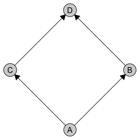

```r
# Create a simple DAG
cg <- caugi(
  A %-->% B + C,
  B %-->% D,
  C %-->% D,
  class = "DAG"
)

# Plot with default settings
plot(cg)
```

By default, `plot()` automatically selects the best layout algorithm based on your graph type. For graphs with only directed edges, it uses the Sugiyama hierarchical layout. For graphs with other edge types, it uses the Fruchterman-Reingold force-directed layout.

## Layout Algorithms

The `caugi` package provides several layout algorithms, each optimized for different use cases.

### Sugiyama (Hierarchical Layout)

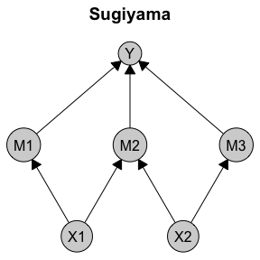

```r
# Create a more complex DAG
dag <- caugi(
  X1 %-->% M1 + M2,
  X2 %-->% M2 + M3,
  M1 %-->% Y,
  M2 %-->% Y,
  M3 %-->% Y,
  class = "DAG"
)

# Use Sugiyama layout explicitly
plot(dag, layout = "sugiyama", main = "Sugiyama")
```

**Best for:** DAGs, causal models, hierarchical structures

**Limitations:** Only works with directed edges

### Fruchterman-Reingold (Spring-Electrical)

The Fruchterman-Reingold layout (Fruchterman and Reingold 1991) uses a physical simulation where edges act as springs and nodes repel each other like charged particles. It produces organic, symmetric layouts with relatively uniform edge lengths.

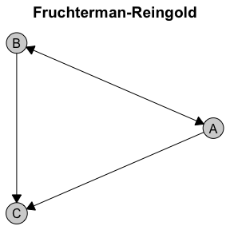

```r
# Create a graph with bidirected edges (ADMG)
admg <- caugi(
  A %-->% C,
  B %-->% C,
  A %<->% B, # Bidirected edge (latent confounder)
  class = "ADMG"
)

# Fruchterman-Reingold handles all edge types
plot(admg, layout = "fruchterman-reingold", main = "Fruchterman-Reingold")
```

**Best for:** General-purpose visualization, graphs with mixed edge types

**Advantages:** Fast, works with all edge types, produces balanced layouts

### Kamada-Kawai (Stress Minimization)

The Kamada-Kawai layout (Kamada and Kawai 1989) minimizes “stress” by making Euclidean distances in the plot proportional to graph-theoretic distances. This produces high-quality layouts that better preserve the global structure compared to Fruchterman-Reingold.

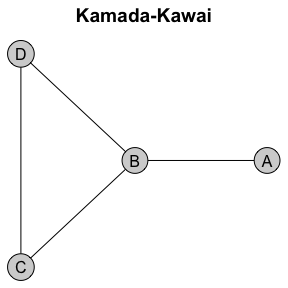

```r
# Create an undirected graph
ug <- caugi(
  A %---% B,
  B %---% C + D,
  C %---% D,
  class = "UG"
)

plot(ug, layout = "kamada-kawai", main = "Kamada-Kawai")
```

**Best for:** Publication-quality figures, when accurate distance representation matters

**Advantages:** Better global structure preservation

### Bipartite Layout

The bipartite layout is designed for graphs with a clear two-group structure, such as treatment/outcome or exposure/response relationships. It arranges nodes in two parallel lines (rows or columns).

Here’s an example bipartite causal graph with treatments and outcomes:

```r
bipartite_graph <- caugi(
  Treatment_A %-->% Outcome_1 + Outcome_2 + Outcome_3,
  Treatment_B %-->% Outcome_1 + Outcome_2,
  Treatment_C %-->% Outcome_2 + Outcome_3,
  class = "DAG"
)
```

Horizontal rows (treatments on top, outcomes on bottom)

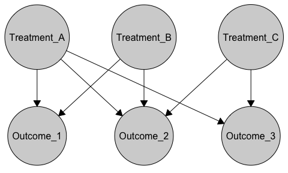

```r
plot(
  bipartite_graph,
  layout = "bipartite",
  orientation = "rows"
)
```

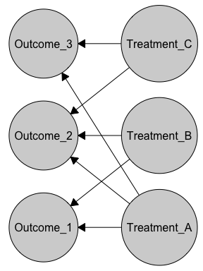

```r
plot(
  bipartite_graph,
  layout = "bipartite",
  orientation = "columns"
)
```

The bipartite layout automatically detects which nodes should be in which partition based on incoming edges. Nodes with no incoming edges are placed in one group, while nodes with incoming edges are placed in the other. You can also specify the partition explicitly:

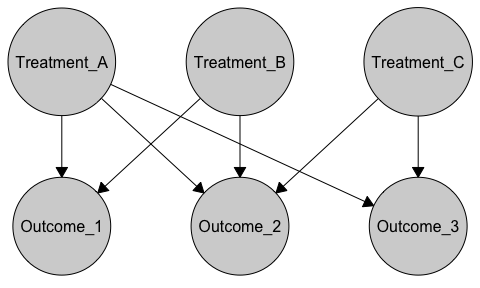

```r
partition <- c(TRUE, TRUE, TRUE, FALSE, FALSE, FALSE)
plot(
  bipartite_graph,
  layout = caugi_layout_bipartite,
  partition = partition,
  orientation = "rows"
)
```

**Best for:** Treatment-outcome structures, exposure-response models, bipartite causal relationships

**Advantages:** Clear visual separation, emphasizes directed relationships between groups

### Tiered Layouts

For graphs with more than two hierarchical levels, the tiered layout places nodes in multiple parallel tiers. This is ideal for visualizing causal structures with clear stages, such as exposures → mediators → outcomes.

First, create a simple three-tier causal graph:

```r
cg_tiered <- caugi(
  X1 %-->% M1 + M2,
  X2 %-->% M1 + M2,
  M1 %-->% Y,
  M2 %-->% Y
)
```

We can define tiers using a named list:

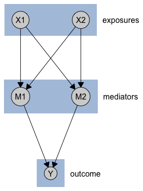

```r
tiers <- list(
  exposures = c("X1", "X2"),
  mediators = c("M1", "M2"),
  outcome = "Y"
)

plot(cg_tiered, layout = "tiered", tiers = tiers, orientation = "rows")
```

The tiered layout supports three input formats:

- named lists,
- named numeric vectors, and
- `data.frame`s.

Named lists is the most intuitive format, and what we have already shown. But you can also use a named numeric vector:

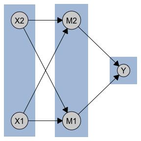

```r
tiers_vector <- c(X1 = 1, X2 = 1, M1 = 2, M2 = 2, Y = 3)
plot(cg_tiered, layout = "tiered", tiers = tiers_vector, orientation = "columns")
```

Finally, you can use a `data.frame` to specify tiers directly.

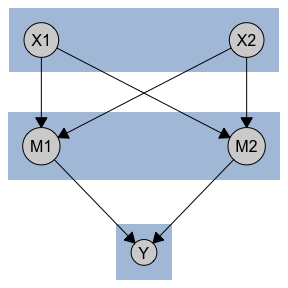

```r
tiers_df <- data.frame(
  name = c("X1", "X2", "M1", "M2", "Y"),
  tier = c(1, 1, 2, 2, 3)
)

layout_df <- caugi_layout_tiered(cg_tiered, tiers_df, orientation = "rows")

plot(cg_tiered, layout = layout_df)
```

**Best for:** Multi-stage causal processes, mediation analysis, temporal sequences, hierarchical structures

**Advantages:** Clear stage separation, flexible tier assignment, supports 2+ tiers, multiple input formats

### Circle Layout

The circle layout places nodes evenly along the perimeter of a circle. The first node is placed at the top and subsequent nodes proceed counter-clockwise. Edge structure is ignored, so the layout is the same for any graph with the same number of nodes.

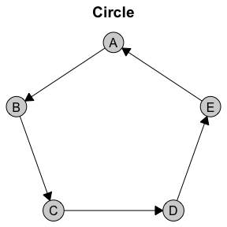

```r
cycle <- caugi(
  A %-->% B,
  B %-->% C,
  C %-->% D,
  D %-->% E,
  E %-->% A
)

plot(cycle, layout = "circle", main = "Circle")
```

**Best for:** Small graphs, cycle visualization, deterministic fallback when edge-based layouts are not informative

**Limitations:** Produces many edge crossings on larger or denser graphs

### Comparing Layouts

You can compute and examine layout coordinates directly using `caugi_layout()`:

```r
layout_sug <- caugi_layout(dag, method = "sugiyama")
layout_fr <- caugi_layout(dag, method = "fruchterman-reingold")
layout_kk <- caugi_layout(dag, method = "kamada-kawai")

# Examine coordinates
head(layout_sug)
```

```
#>   name    x   y
#> 1   X1 0.25 0.0
#> 2   X2 0.75 0.0
#> 3   M1 0.00 0.5
#> 4   M2 0.50 0.5
#> 5   M3 1.00 0.5
#> 6    Y 0.50 1.0
```

## Customizing Plots

The `plot()` function provides extensive customization options for nodes, edges, and labels.

### Node Styling

You can customize the appearance of nodes using the `node_style` parameter. Styles may be applied globally (to all nodes) or locally (to specific nodes).

Apply the same style to all nodes:

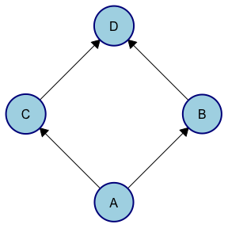

```r
plot(
  cg,
  node_style = list(
    fill = "lightblue", # Fill color
    col = "darkblue", # Border color
    lwd = 2, # Border width
    padding = 4, # Text padding (mm)
    size = 1.2 # Size multiplier
  )
)
```

Customize styles for individual nodes using the `by_node` option:

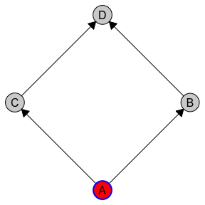

```r
plot(
  cg,
  node_style = list(
    by_node = list(
      A = list(fill = "red", col = "blue", lwd = 2),
      B = list(padding = "2")
    )
  )
)
```

Available node style parameters:

- **Appearance (passed to `gpar()`)**: `fill`, `col`, `lwd`, `lty`, `alpha`
- **Geometry**: `padding` (text padding in mm), `size` (node size multiplier)

### Edge Styling

You can customize edge appearance using the `edge_style` parameter. Styles can be applied globally, by edge type, by source node, or to individual edges.

Apply the same styling to all edges in the graph:

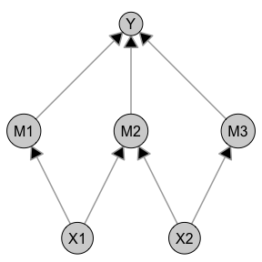

```r
plot(
  dag,
  edge_style = list(
    col = "darkgray", # Edge color
    lwd = 1.5, # Edge width
    arrow_size = 4 # Arrow size (mm)
  )
)
```

Customize different edge types (e.g., directed vs. bidirected edges):

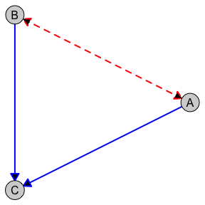

```r
plot(
  admg,
  layout = "fruchterman-reingold",
  edge_style = list(
    directed = list(col = "blue", lwd = 2),
    bidirected = list(col = "red", lwd = 2, lty = "dashed")
  )
)
```

Apply styling to all edges from a given node:

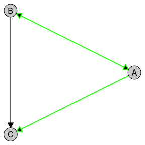

```r
plot(
  admg,
  layout = "fruchterman-reingold",
  edge_style = list(
    by_edge = list(
      A = list(col = "green", lwd = 2)
    )
  )
)
```

Target an individual edge between two nodes:

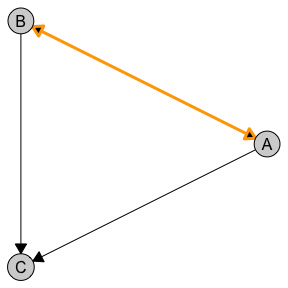

```r
plot(
  admg,
  layout = "fruchterman-reingold",
  edge_style = list(
    by_edge = list(
      A = list(
        B = list(col = "orange", lwd = 3)
      )
    )
  )
)
```

The style precedence is as follows (highest to lowest):

1. Specific edge (`by_edge` with both from and to nodes)
2. All edges from a node (`by_edge` with only from node)
3. Per-type edge styles (`directed`, `undirected`, etc.)
4. Global edge styles

The example below combines global, per-type, per-node, and per-edge styling in a single plot. More specific styles override more general ones according to the precedence rules above.

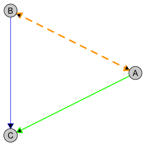

```r
plot(
  admg,
  layout = "fruchterman-reingold",
  edge_style = list(
    # Global defaults
    col = "gray80",
    lwd = 1,

    # Per-type styling
    directed = list(col = "blue"),
    bidirected = list(col = "red", lty = "dashed"),

    # All edges from node A
    by_edge = list(
      A = list(
        col = "green",
        lwd = 2,

        # Specific edge A -> B
        B = list(
          col = "orange",
          lwd = 3
        )
      )
    )
  )
)
```

Available edge style parameters:

- **Appearance (passed to `gpar()`)**: `col`, `lwd`, `lty`, `alpha`, `fill`
- **Geometry**: `arrow_size` (arrow length in mm), `circle_size` (radius of endpoint circles for partial edges in mm), `route` (logical, automatic edge routing; see below)
- **Per-type options**: `directed`, `undirected`, `bidirected`, `partial`

#### Automatic Edge Routing

When an edge would pass straight through a node it does not connect to, the edge is hard to distinguish from edges that actually touch that node. This happens most often with collinear nodes—for example three nodes in the same tier, where the edge between the outer two runs right through the middle one—but also whenever a long edge happens to cross an unrelated node.

By default (`route = TRUE`), `plot()` detects these cases from the node positions and sizes and gently bends the offending edge around the node, leaving all node positions untouched:

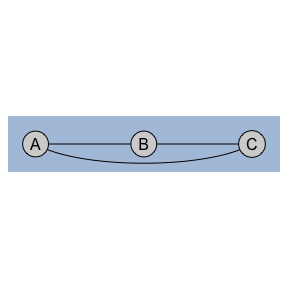

```r
cg_clique <- caugi(A %---% B + C, B %---% C)
tiers_clique <- list(c("A", "B", "C"))
layout_clique <- caugi_layout_tiered(
  cg_clique,
  tiers_clique,
  orientation = "rows"
)

# A --- C bends around B (default); set route = FALSE to draw straight edges
plot(cg_clique, layout = layout_clique)
```

Because routing is a draw-time operation, it works the same whether you let `plot()` compute the layout or pass a pre-computed one. Disable it globally, by edge type, or per edge through the usual `edge_style` overrides:

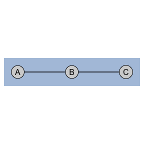

```r
plot(cg_clique, layout = layout_clique, edge_style = list(route = FALSE))
```

#### Partial Edges

Partial edges (`o->` and `o-o`) are rendered with circles at their endpoints to indicate uncertainty about edge orientation. These edges appear in PAGs (Partial Ancestral Graphs). You can customize the circle size:

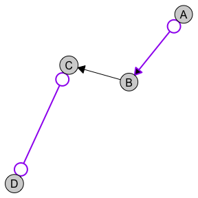

```r
g <- caugi(
  A %o->% B,
  B %-->% C,
  C %o-o% D,
  class = "UNKNOWN"
)

plot(
  g,
  edge_style = list(
    partial = list(
      col = "purple",
      lwd = 2,
      circle_size = 2.5 # Larger circles (default is 1.5)
    )
  )
)
```

### Label Styling

Customize node labels with the `label_style` parameter:

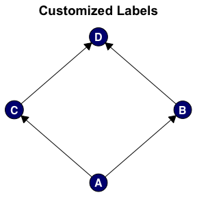

```r
plot(
  cg,
  main = "Customized Labels",
  label_style = list(
    col = "white", # Text color
    fontsize = 12, # Font size
    fontface = "bold", # Font face
    fontfamily = "sans" # Font family
  ),
  node_style = list(
    fill = "navy" # Dark background for white text
  )
)
```

Available label style parameters (passed to `gpar()`):

- `col`, `fontsize`, `fontface`, `fontfamily`, `cex`

### Styling Tiered Layouts

By default, tiered layouts are plotted with boxes around each tier and labels indicating the tier names (if provided).

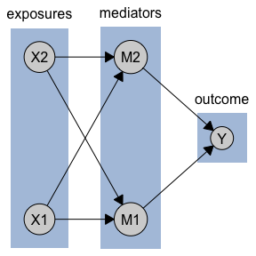

```r
plot(cg_tiered, tiers = tiers)
```

But you can customize the appearance of tier boxes using the `tier_style` parameter. Here, for instance, we specify different fill colors for each tier using a vector.

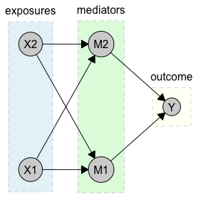

```r
plot(
  cg_tiered,
  tiers = tiers,
  tier_style = list(
    fill = c("lightblue", "lightgreen", "lightyellow"),
    col = "gray50",
    lty = 2,
    alpha = 0.3
  )
)
```

For more granular control, you can specify styles for individual tiers. Here, we customize the “exposures” and “outcome” tiers specifically:

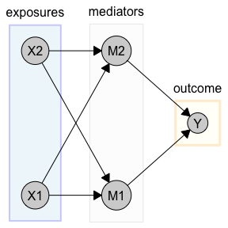

```r
plot(
  cg_tiered,
  tiers = tiers,
  tier_style = list(
    fill = "gray95",
    col = "gray60",
    alpha = 0.2,
    by_tier = list(
      exposures = list(
        fill = "lightblue",
        col = "blue",
        lwd = 2
      ),
      outcome = list(
        fill = "lightyellow",
        col = "orange",
        lwd = 3,
        lty = 1
      )
    )
  )
)
```

Labels for the tiers can also be customized. Here, for example, we change the font size and color of the tier labels:

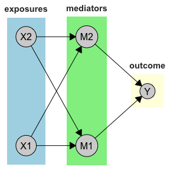

```r
plot(
  cg_tiered,
  tiers = tiers, # Named list: exposures, mediators, outcome
  tier_style = list(
    fill = c("lightblue", "lightgreen", "lightyellow"),
    label_style = list(
      fontsize = 11,
      fontface = "bold",
      col = "gray20"
    )
  )
)
```

You can also provide custom labels for each tier instead of using the names from the tiers object

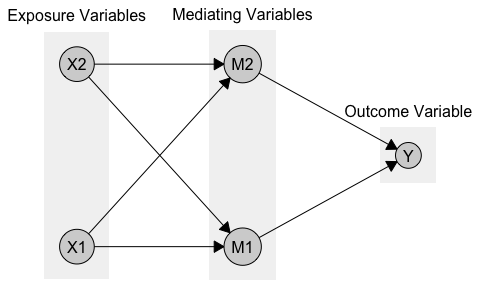

```r
plot(
  cg_tiered,
  tiers = tiers,
  tier_style = list(
    fill = "gray95",
    labels = c("Exposure Variables", "Mediating Variables", "Outcome Variable")
  )
)
```

If you don’t want any boxes or labels around the tiers, you can disable them:

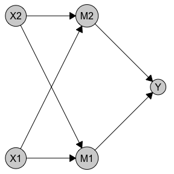

```r
plot(
  cg_tiered,
  tiers = tiers,
  tier_style = list(boxes = FALSE, labels = FALSE)
)
```